# AF PRS vs. AF after revascularization

**Libraries**

```r
#setwd("/finngen/red/cabg_prs")

#install.packages("/home/ivm/R/src/packrat_0.5.0.tar.gz", repos=NULL, type="source")
#install.packages("/finngen/green/tableone_0.12.0.tar.gz", repos=NULL, type="source")
#install.packages("/finngen/green/compareC_1.3.1.tar.gz", repos=NULL, type="source")

packrat::on()
library(tidyverse)
library(survival)   # survival analysis

library(data.table) # fread() function
library(gridExtra)  # plots to grid
library(survminer)  # ggbased visualization and extra diagnostics
library(survRM2)    # restricted mean survival times
library(visdat)     # visualization of tibble and na's
library(forestplot) # forestplot
library(compareC)   # compare c-index
library(kableExtra) # Pretty tables
library(tableone)   # Characteristics table

source('/finngen/red/cabg_prs/scripts/functions2.R')

data_path <- "/finngen/red/cabg_prs/data"
prs_path <- "/finngen/red/cabg_prs/data/ukb_prs"
fig_path <- "/finngen/red/cabg_prs/figs"
```

# 1 Data

## 1.1 Variables

**Operations**

- I9_CABG, Coronary artery bypass crafting
- I9_ANGIO, Coronary angiopasty
- I9_REVASC, I9_CABG OR I9_ANGIO

Three samples: patients *after* CABG, ANGIO and REVASC.

**For polygenic riskscores**

- I9_AF (ukb: 20002_1471), Atrial fibrillation

**For clinical riskscore CHA<sub>2</sub>DS<sub>2</sub>-VASc:**

- Congestive heart failure = I9_HEARTFAIL
- Hypertension = I9_HYPTENS
- Diabetes mellitus = E4_DIABETES
- Stroke, TIA, or TE = C_STROKE
- Vascular disease = I9_MI or I9_PAD

## 1.2 Download & preprocess data

**Copying and preprocessing outside R**

Endpoint and covariate files transfered and unzipped. Columns selected from endpoint file prior to import to r, because the original phenotype file is very large.

```bash
#Endpoint file and covariate files unzipped
phenodir="/finngen/red/cabg_prs/data/phenotypes"
gzip -dc /finngen/library-red/finngen_R6/phenotype_2.0/data/finngen_R6_v2_endpoint.gz > $phenodir/finngen_R6_v2_endpoint
gzip -dc /finngen/library-red/finngen_R6/phenotype_2.0/data/finngen_R6_cov_pheno_1.0.txt.gz > $phenodir/finngen_R6_cov_pheno_1.0.txt

#Self written perl-script to extract columns from phenotype file (runned from directory 'scripts')
phenodir="/finngen/red/cabg_prs/data/phenotypes"
perl select_columns.pl $phenodir/finngen_R6_v2_endpoint       $phenodir/finngen_R6_v2_CABG    fg_pheno_cols.txt &
perl select_columns.pl $phenodir/finngen_R6_cov_pheno_1.0.txt $phenodir/R6_cov_pheno_selected fg_cov_cols.txt &
perl select_columns.pl $phenodir/finngen_R6_v2_endpoint       $phenodir/finngen_R6_v2_chadsvasc    fg_chadsvasc_cols.txt &
```

**Loading and combining the data**

Downloading the data.

```r
names_in <- list("I9_AF")

#PRS scores
prs_df <- lapply(names_in, function(name) {
  fread(str_glue("{prs_path}/ukb.{name}.both_sexes.profile")) %>%
        select(IID, SCORE) %>%
      rename(FINNGENID = IID, !!paste(name, "SCORE", sep="_") := SCORE)}
  ) %>%
  reduce(left_join, by = "FINNGENID")

#endpoints and covariates
phenotypes <- fread(str_glue("{data_path}/phenotypes/finngen_R6_v2_CABG"), sep = "\t")
covs_in <- fread(str_glue("{data_path}/phenotypes/R6_cov_pheno_selected"), sep = "\t")
pheno_chdvsc <- fread(str_glue("{data_path}/phenotypes/finngen_R6_v2_chadsvasc"), sep = "\t") %>%
  select(-contains('MI')) #To avoid duplicates
```

Combining the data.

```r
df <- phenotypes %>%
  left_join(prs_df, by = "FINNGENID") %>%
  left_join(covs_in, by = "FINNGENID") %>%
  left_join(pheno_chdvsc, by = "FINNGENID") %>%
  as_tibble() %>%
  mutate_at(c("batch","cohort"),as.factor)
```

**Preprocess**

Removing individuals without genetic information. Also endpointnames are simplified.

```r
#
#glimpse(df)
#vis_dat(sample_n(df, 10000))
df <- df %>% filter(!is.na(batch)) %>%
  rename_at(vars(contains('I9_')), list(~str_remove(., "I9_"))) %>%
  rename_at(vars(contains('K11_')), list(~str_remove(., "K11_"))) %>%
  rename_at(vars(contains('E4_')), list(~str_remove(., "E4_"))) %>%
  rename_at(vars(contains('C_STRO')), list(~str_remove(., "C_"))) %>%
  rename_at(vars(contains('ANGIO')), list(~str_replace(., "ANGIO", "PCI")))
#vis_dat(sample_n(df, 10000))

#Number of individuals:
#dim(df)[1]
```

Creating scaled & categorical variables.

```r
#my_probs = c(0 ,0.2, 0.8, 1)
#my_labels =  c(">20%","20-80%",">80")

#my_probs = c(0 , 0.1, 0.2, 0.8, 0.9, 1)
#my_labels =  c(">10%", "10-20%", "20-80%", "80-90%", ">90%")

my_probs = c(0,0.025,0.2,0.8,0.975,1)
my_labels =  c("<2.5%","2.5-20%","20-80%","80-97.5%",">97.5%")

df <- df %>%
  mutate(AF_SCALED = scale(AF_SCORE),
         AF_CAT = cut(AF_SCORE, breaks=quantile(df$AF_SCORE, my_probs),
                            labels=my_labels, include.lowest = T))
```

**Variable names redefined**

```r
names_oper <- list("REVASC", "CABG", "PCI")
names_ep <- list("AF")
```

**Number of individuals, AF, sex and age**

Age is age at end of followup.

```r
#Sex and age
df %>%
  summarise(N=n(), N_AF = sum(AF, na.rm = T), AF_perc = mean(AF, na.rm = T)*100 ,N_fem = sum(SEX_IMPUTED), fem_perc = mean(SEX_IMPUTED)*100, end_age = mean(FU_END_AGE), end_age_sd = sd(FU_END_AGE)) %>%
    knitr::kable(digits=1) %>%  kable_styling()
```

| N | N_AF | AF_perc | N_fem | fem_perc | end_age | end_age_sd |
| --- | --- | --- | --- | --- | --- | --- |
| 260405 | 28670 | 17.4 | 147061 | 56.5 | 59.5 | 17.6 |

## 1.3 Subset the data by operations

**Create datasets for each operations**

Lists with three datasets for each operations created

```r
#Datasets for each operation are filtered.
#As FinnGen assignes NA's to similar endpoints, we must replace NA's for
#AF and MI by zero, or they do not have observations.

dfs.oper <- lapply(names_oper, function(name){
    df %>% filter(get(name) == 1) %>%
    mutate(AF = if_else(is.na(AF), as.integer(0), AF),
           MI = if_else(is.na(MI), as.integer(0), MI))
  }) %>% setNames(names_oper)
```

**CHA<sub>2</sub>DS<sub>2</sub>-VASc score**

```r
#Chadsvasc score:

dfs.oper <- lapply(names_oper, function(oper){

  oper_age <- str_glue("{oper}_AGE")
  dfs.oper[[oper]] %>%
  mutate(MIPAD = if_else(MI|PAD, 1, 0)) %>%
  rowwise()%>%
  mutate(MIPAD_AGE = min(MI_AGE, PAD_AGE)) %>%
  ungroup() %>%
  mutate(CVSC_AGE_65 = if_else(get(oper_age) >= 65, 1, 0),
         CVSC_AGE_75 = if_else(get(oper_age) >= 75, 1, 0),
         CVSC_AGE_65_75 = if_else((CVSC_AGE_65 == 1 & CVSC_AGE_75 == 0),1, 0),
         CVSC_HEARTFAIL = if_else(HEARTFAIL_AGE < get(oper_age), 1, 0),
         CVSC_HYPTENS = if_else(HYPTENS_AGE < get(oper_age), 1, 0),
         CVSC_DIABETES = if_else(DIABETES_AGE < get(oper_age), 1, 0),
         CVSC_STROKE = if_else(STROKE_AGE < get(oper_age), 1, 0),
         CVSC_MIPAD = if_else(MIPAD_AGE < get(oper_age), 1, 0),
         CVSC = CVSC_HEARTFAIL + CVSC_HYPTENS + CVSC_AGE_75 + CVSC_DIABETES +
           2*CVSC_STROKE + CVSC_MIPAD + CVSC_AGE_65 + SEX_IMPUTED,
         CVSC_SCALED = scale(CVSC))

}) %>% setNames(names_oper)
```

Correlation between clinical and genetic score:

```r
#Pearson
lapply(names_oper, function(oper){
  cor(dfs.oper[[oper]][["CVSC_SCALED"]],dfs.oper[[oper]][["AF_SCALED"]], method = "pearson")
})%>% setNames(names_oper) %>% unlist()
```

```
##       REVASC         CABG          PCI
## -0.002504301 -0.016284641  0.006363315
```

```r
#Spearman
lapply(names_oper, function(oper){
  cor(dfs.oper[[oper]][["CVSC_SCALED"]],dfs.oper[[oper]][["AF_SCALED"]], method = "spearman")
})%>% setNames(names_oper) %>% unlist()
```

```
##        REVASC          CABG           PCI
## -0.0008906674 -0.0120234571  0.0060007410
```

**Prevalent cases removed**

```r
#Datasets for each operation are filtered and added to list

covs <- c("SEX_IMPUTED", "batch", "BL_YEAR","PC1", "PC2", "PC3", "PC4", "PC5", "PC6", "PC7", "PC8","PC9", "PC10")

#Lists of dataframes for each operations and each endpoint of interest
#PREVALENT ARE REMOVED

dfs <- lapply(names_oper, function(oper){
  my_create_sub_dfs(oper, dfs.oper, names_ep, covs) }) %>%
  setNames(names_oper)

#list of dataframes is simplified as we have now only one endpoint of interest, AF
dfs.af <- lapply(names_oper, function(oper){
  dfs[[oper]][["AF"]] }) %>%
  setNames(names_oper)
```

## 1.4 Characteristics tables for each operations

Here all characteristics are at the age of operation.

```r
myVars <-   c("AF_AGE", "SEX_IMPUTED", "CVSC", "CVSC_HEARTFAIL", "CVSC_HYPTENS", "CVSC_AGE_75", "CVSC_DIABETES",
              "CVSC_STROKE", "CVSC_MIPAD", "CVSC_AGE_65_75")

catVars <-  c("SEX_IMPUTED", "CVSC_HEARTFAIL", "CVSC_HYPTENS", "CVSC_AGE_75", "CVSC_DIABETES",
              "CVSC_STROKE", "CVSC_MIPAD", "CVSC_AGE_65_75")

chr_rownames <- c("Age, years (SD)", "Women, n (%)", "CHA2DS2-VASc score (SD)", "Hearth failure, n (%)", "Hypertension, n (%)", "Age > 74, n (%)",
              "Diabetes, n (%)", "Prior stroke or TIA, n (%)", "Vascular disease, n (%)", "Age 65-75, n (%)")

my_char_table(dfs.af[["REVASC"]], "AF", myVars, catVars, chr_rownames, name="REVASC") %>%
  knitr::kable() %>% kable_styling()
```

|  | Overall | AF | No AF |
| --- | --- | --- | --- |
| REVASC | 13082 | 3556 | 9526 |
| Age, years (SD) | 73.30 (9.57) | 72.51 (9.29) | 73.60 (9.66) |
| Women, n (%) | 3169 (24.2) | 777 (21.9) | 2392 (25.1) |
| CHA2DS2-VASc score (SD) | 1.95 (1.57) | 2.12 (1.58) | 1.89 (1.57) |
| Hearth failure, n (%) | 1130 ( 8.6) | 448 (12.6) | 682 ( 7.2) |
| Hypertension, n (%) | 5251 (40.1) | 1573 (44.2) | 3678 (38.6) |
| Age > 74, n (%) | 1777 (13.6) | 518 (14.6) | 1259 (13.2) |
| Diabetes, n (%) | 2796 (21.4) | 705 (19.8) | 2091 (22.0) |
| Prior stroke or TIA, n (%) | 1039 ( 7.9) | 320 ( 9.0) | 719 ( 7.5) |
| Vascular disease, n (%) | 3495 (26.7) | 1117 (31.4) | 2378 (25.0) |
| Age 65-75, n (%) | 4060 (31.0) | 1228 (34.5) | 2832 (29.7) |

```r
my_char_table(dfs.af[["CABG"]], "AF", myVars, catVars, chr_rownames, name="CABG") %>%
  knitr::kable() %>% kable_styling()
```

|  | Overall | AF | No AF |
| --- | --- | --- | --- |
| CABG | 6132 | 2127 | 4005 |
| Age, years (SD) | 74.07 (8.88) | 72.51 (8.98) | 74.90 (8.71) |
| Women, n (%) | 1118 (18.2) | 377 (17.7) | 741 (18.5) |
| CHA2DS2-VASc score (SD) | 2.10 (1.57) | 2.15 (1.60) | 2.07 (1.56) |
| Hearth failure, n (%) | 713 (11.6) | 310 (14.6) | 403 (10.1) |
| Hypertension, n (%) | 2752 (44.9) | 974 (45.8) | 1778 (44.4) |
| Age > 74, n (%) | 699 (11.4) | 234 (11.0) | 465 (11.6) |
| Diabetes, n (%) | 1475 (24.1) | 437 (20.5) | 1038 (25.9) |
| Prior stroke or TIA, n (%) | 496 ( 8.1) | 206 ( 9.7) | 290 ( 7.2) |
| Vascular disease, n (%) | 2435 (39.7) | 866 (40.7) | 1569 (39.2) |
| Age 65-75, n (%) | 1983 (32.3) | 731 (34.4) | 1252 (31.3) |

```r
my_char_table(dfs.af[["PCI"]], "AF", myVars, catVars, chr_rownames, name="PCI") %>%
  knitr::kable() %>% kable_styling()
```

|  | Overall | AF | No AF |
| --- | --- | --- | --- |
| PCI | 8296 | 1854 | 6442 |
| Age, years (SD) | 72.79 (9.89) | 72.48 (9.44) | 72.88 (10.01) |
| Women, n (%) | 2312 (27.9) | 477 (25.7) | 1835 (28.5) |
| CHA2DS2-VASc score (SD) | 1.96 (1.61) | 2.24 (1.59) | 1.89 (1.60) |
| Hearth failure, n (%) | 626 ( 7.5) | 240 (12.9) | 386 ( 6.0) |
| Hypertension, n (%) | 3212 (38.7) | 823 (44.4) | 2389 (37.1) |
| Age > 74, n (%) | 1296 (15.6) | 355 (19.1) | 941 (14.6) |
| Diabetes, n (%) | 1778 (21.4) | 394 (21.3) | 1384 (21.5) |
| Prior stroke or TIA, n (%) | 699 ( 8.4) | 166 ( 9.0) | 533 ( 8.3) |
| Vascular disease, n (%) | 1793 (21.6) | 509 (27.5) | 1284 (19.9) |
| Age 65-75, n (%) | 2587 (31.2) | 665 (35.9) | 1922 (29.8) |

# 2 Survival analysis

**AF after each three operation :**

- Model1: Covariates: {oper}_AGE, SEX_IMPUTED, batch, BL_YEAR, PC1:PC10
- Model2: Covariates: CHA<sub>2</sub>DS<sub>2</sub>-VASc, {oper}_AGE, SEX_IMPUTED, batch, BL_YEAR, PC1:PC10

## 2.1 Proportional hazard assumption: log log curve

**KM & log log curves**

**Model by survfit**

```r
kms <-
  lapply(names_oper, function(oper){
    lapply(names_ep, function(ep){
      survfit(Surv(AGE_DIFF, get(ep)) ~ get(str_glue("{ep}_CAT")), data=dfs[[oper]][[ep]])
    }) %>% setNames(names_ep)
  }) %>% setNames(names_oper)
```

**KM plots**

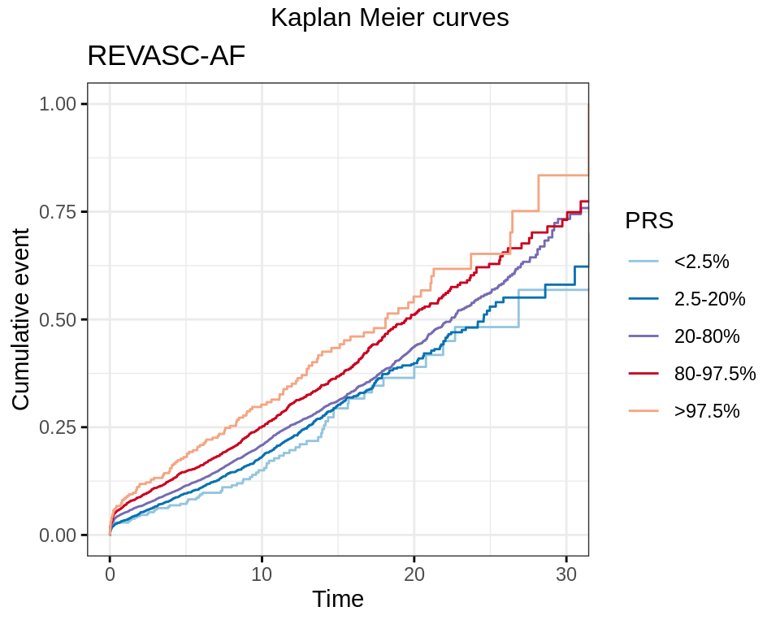

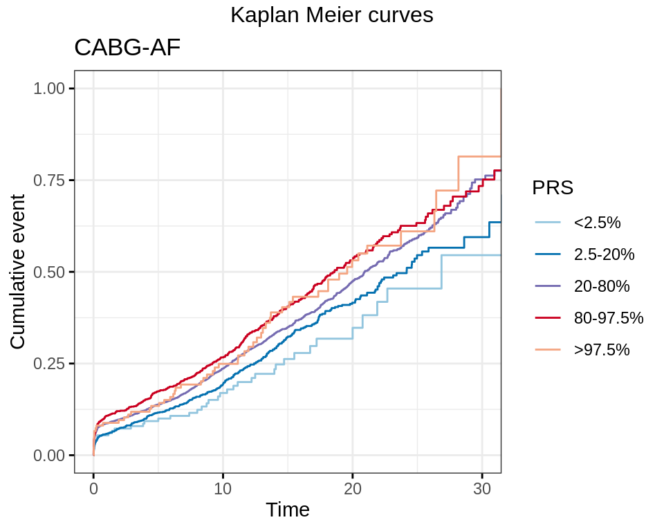

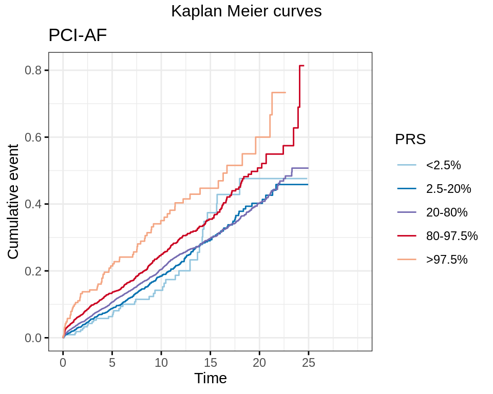

```r
for(oper in unlist(names_oper)) {
  ep=names_ep[[1]]   #Tämän alustuksen tarve on kyllä ihme juttu. Suoritus kaatuu ilman sitä.

  plot_list <- lapply(names_ep, function(ep){
    #print(str_glue("{oper}-{ep}"))
    my_ggkmplot(kms[[oper]][[ep]], str_glue("{oper}-{ep}"), my_labels, isFive=T)
  })
  plots <- arrange_ggsurvplots(plot_list, nrow = 1, ncol = 1, title = "Kaplan Meier curves")
  #ggsave(file = str_glue("{fig_path}/km.prs.after.{oper}.png"), plot = plots, height = 6, width = 12, dpi = 200)
}
```

**log log curve**

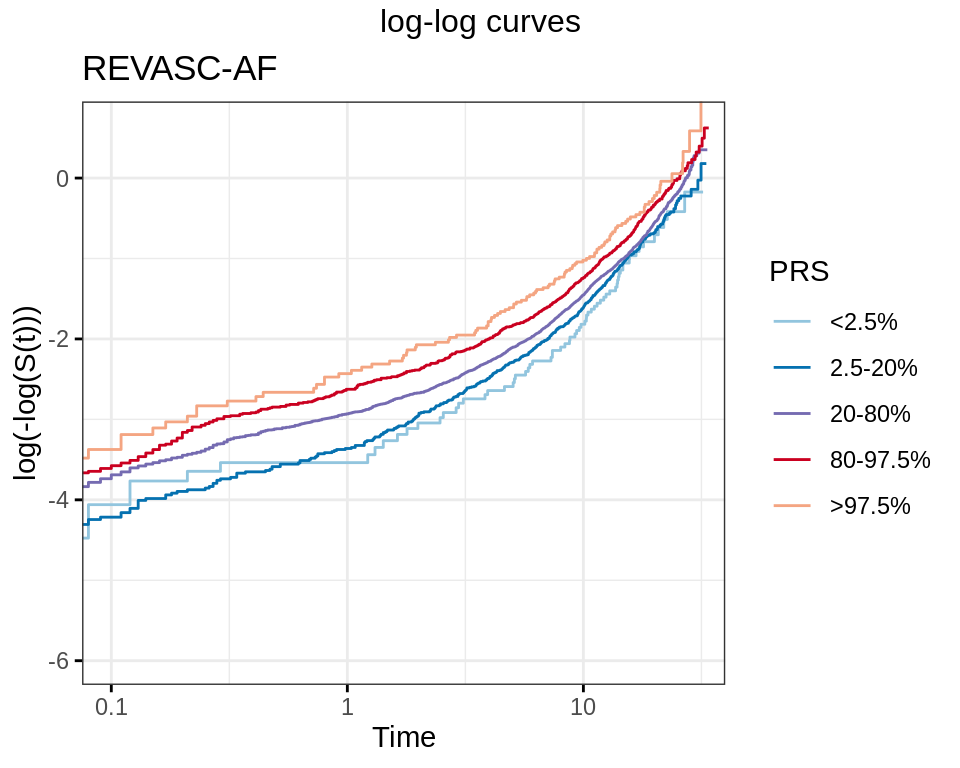

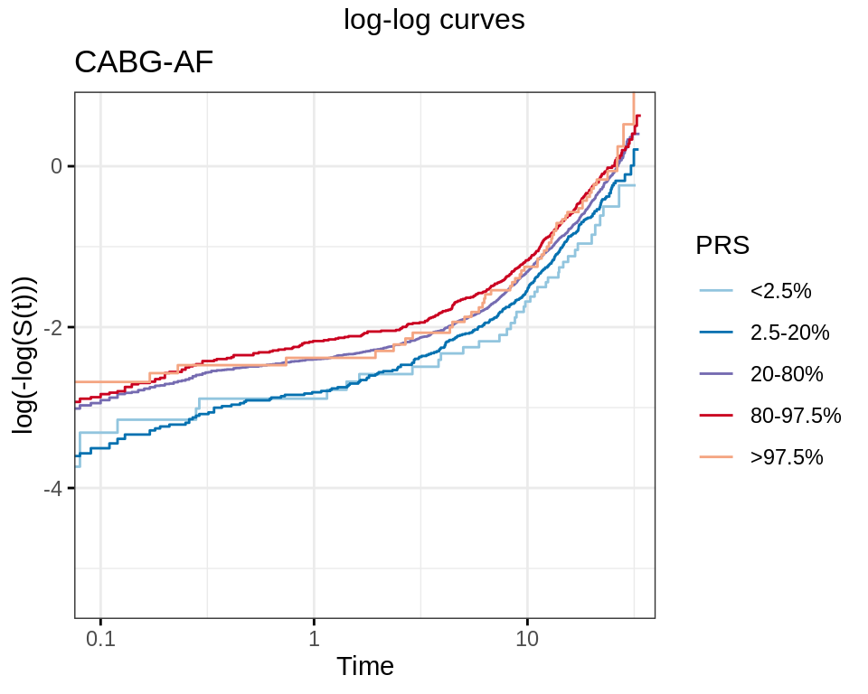

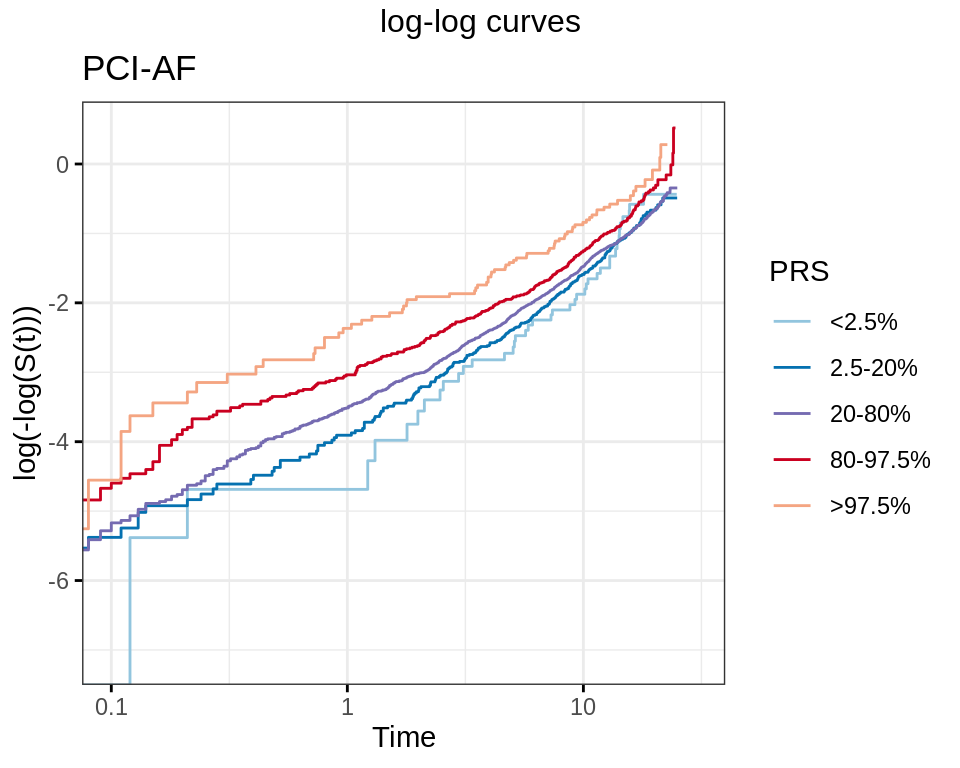

```r
for(oper in unlist(names_oper)) {
  ep=names_ep[[1]]   #Tämän alustuksen tarve on kyllä ihme juttu. Suoritus kaatuu ilman sitä.

  plot_list <- lapply(names_ep, function(ep){
    #print(str_glue("{oper}-{ep}"))
    my_ggkmplot(kms[[oper]][[ep]], str_glue("{oper}-{ep}"), my_labels, fun="cloglog", xlim=c(0.1,30), isFive=T)

  })
  plots <- arrange_ggsurvplots(plot_list, nrow = 1, ncol = 1, title = "log-log curves")
  #ggsave(file = str_glue("{fig_path}/log.prs.after.{oper}.png"), plot = plots, height = 6, width = 12, dpi = 200)
}
```

## 2.2 Cox model: covariate adjusted, continuous score

**Running models**

```r
covs_f<- paste(covs, collapse = " + ")

# Model1, only PRS
ep <- "AF"

cxs.cs.prs <-
  lapply(names_oper, function(oper){
      my_formula <- str_glue("Surv(AGE_DIFF, {ep}) ~ {ep}_SCALED + {oper}_AGE + {covs_f}")
      coxph(as.formula(my_formula), data=dfs.af[[oper]])
  }) %>% setNames(names_oper)

# Model2, PRS + CHADSVASC

cxs.cs.both <-
  lapply(names_oper, function(oper){
      my_formula <- str_glue("Surv(AGE_DIFF, {ep}) ~ {ep}_SCALED + CVSC_SCALED + {oper}_AGE + {covs_f}")
      coxph(as.formula(my_formula), data=dfs.af[[oper]])
  }) %>% setNames(names_oper)

# Model3, only CHADSVASC

cxs.cs.cvsc <-
  lapply(names_oper, function(oper){
      my_formula <- str_glue("Surv(AGE_DIFF, {ep}) ~ CVSC_SCALED + {oper}_AGE + {covs_f}")
      coxph(as.formula(my_formula), data=dfs.af[[oper]])
  }) %>% setNames(names_oper)
```

**Table: Hazard rations**

```r
hr.cs.tables <-
  lapply(names_oper, function(oper){

  nN <- dfs.af[[oper]] %>%
    summarize(sum(AF), n()-sum(AF)) %>%
    unite("nN", sep="/")

  rbind(my_extr_coef(cxs.cs.prs[[oper]], "Model 1: PRS", select="AF_SCALED"),
        my_extr_coef(cxs.cs.both[[oper]], "Model 2: PRS+cdsvasc", select="AF_SCALED")) %>%
    my_tidy_table() %>%
    cbind(.,nN) %>%
    select(name, est, pval, nN) %>%
    rename(!!oper := name, `HR (95% CI)` = est, `P-value` = pval, `Cases/Controls` = nN) #%>%
    #mutate("P-value" = sub("e(-\\d+)", "x10<sup>\\1</sup>", `P-value`, perl=T))   #html-version/proper exponents

}) %>% setNames(names_oper)

hr.cs.tables$REVASC %>% knitr::kable() %>% kable_styling()
```

| REVASC | HR (95% CI) | P-value | Cases/Controls |
| --- | --- | --- | --- |
| Model 1: PRS | 1.18 (1.14-1.22) | 5.1e-23 | 3556/9526 |
| Model 2: PRS+cdsvasc | 1.19 (1.15-1.23) | 6.8e-24 | 3556/9526 |

```r
hr.cs.tables$CABG %>% knitr::kable() %>% kable_styling()
```

| CABG | HR (95% CI) | P-value | Cases/Controls |
| --- | --- | --- | --- |
| Model 1: PRS | 1.15 (1.1-1.2) | 1e-10 | 2127/4005 |
| Model 2: PRS+cdsvasc | 1.16 (1.11-1.21) | 1.5e-11 | 2127/4005 |

```r
hr.cs.tables$PCI %>% knitr::kable() %>% kable_styling()
```

| PCI | HR (95% CI) | P-value | Cases/Controls |
| --- | --- | --- | --- |
| Model 1: PRS | 1.22 (1.16-1.28) | 5.7e-17 | 1854/6442 |
| Model 2: PRS+cdsvasc | 1.22 (1.17-1.28) | 2.2e-17 | 1854/6442 |

*Sex & age of operation included*

```r
#SEX and AGE
my_cxlist_to_hrtable_selected(cxs.cs.prs, "name", select="SEX|AGE") %>%
  knitr::kable(digits=2) %>%
  kable_styling()
```

| name | Variable | HR (95% CI) | P-value |
| --- | --- | --- | --- |
| REVASC | REVASC_AGE | 1.06 (1.05-1.06) | 4.6e-180 |
| REVASC | SEX_IMPUTED | 0.86 (0.79-0.93) | 0.00028 |
| CABG | CABG_AGE | 1.06 (1.06-1.07) | 1.3e-109 |
| CABG | SEX_IMPUTED | 0.94 (0.84-1.06) | 0.3 |
| PCI | PCI_AGE | 1.06 (1.05-1.06) | 7.5e-98 |
| PCI | SEX_IMPUTED | 0.8 (0.72-0.89) | 6.7e-05 |

**All coefficients**

```r
lapply(cxs.cs.prs, print)
```

```
## Call:
## coxph(formula = as.formula(my_formula), data = dfs.af[[oper]])
##
##                                                        coef  exp(coef)
## AF_SCALED                                         1.670e-01  1.182e+00
## REVASC_AGE                                        5.680e-02  1.058e+00
## SEX_IMPUTED                                      -1.533e-01  8.578e-01
## batchAxiomGT1_b02_V2P2.calls                      1.398e-01  1.150e+00
## batchAxiomGT1_b03_V2P2.calls                      1.587e-01  1.172e+00
## batchAxiomGT1_b04_V2P2.calls                      3.121e-01  1.366e+00
## batchAxiomGT1_b05_V2P2.calls                      2.779e-01  1.320e+00
## batchAxiomGT1_b06_V2P2.calls                      1.651e-01  1.180e+00
## batchAxiomGT1_b07_V2P2.calls                      3.462e-01  1.414e+00
## batchAxiomGT1_b08_V2P2.calls                      2.896e-01  1.336e+00
## batchAxiomGT1_b09_V2P2.calls                      2.894e-01  1.336e+00
## batchAxiomGT1_b10_V2P2.calls                      4.391e-01  1.551e+00
## batchAxiomGT1_b11_V2P2.calls                      2.758e-01  1.318e+00
## batchAxiomGT1_b12_V2P2.calls                      2.294e-01  1.258e+00
## batchAxiomGT1_b13_V2P2.calls                      6.973e-01  2.008e+00
## batchAxiomGT1_b14_V2P2.calls                      3.538e-01  1.425e+00
## batchAxiomGT1_b15_V2P2.calls                      6.574e-01  1.930e+00
## batchAxiomGT1_b16_V2P2.calls                      3.658e-01  1.442e+00
## batchAxiomGT1_b17_V2P2.calls                      1.619e-01  1.176e+00
## batchAxiomGT1_b18_V2P2.calls                      3.078e-01  1.360e+00
## batchAxiomGT1_b19_V2P2.calls                      3.438e-01  1.410e+00
## batchAxiomGT1_b20_V2P2.calls                      4.240e-01  1.528e+00
## batchAxiomGT1_b21_V2P2.calls                      5.096e-01  1.665e+00
## batchAxiomGT1_b22_V2P2.calls                      6.283e-01  1.874e+00
## batchAxiomGT1_b23_V2P2.calls                      3.916e-01  1.479e+00
## batchAxiomGT1_b24_V2P2.calls                      2.465e-01  1.280e+00
## batchAxiomGT1_b25_V2P2.calls                      4.714e-01  1.602e+00
## batchAxiomGT1_b26_V2P2.calls                      2.805e-01  1.324e+00
## batchAxiomGT1_b27_V2P2.calls                      2.388e-01  1.270e+00
## batchAxiomGT1_b28_V2P2.calls                      1.265e-01  1.135e+00
## batchAxiomGT1_b29_V2P2.calls                      4.490e-01  1.567e+00
## batchAxiomGT1_b30_V2P2.calls                      5.239e-01  1.689e+00
## batchAxiomGT1_b31_V2.calls                        3.878e-01  1.474e+00
## batchAxiomGT1_b3234_V2.calls                      3.419e-01  1.408e+00
## batchAxiomGT1_b33_V2.calls                        3.082e-01  1.361e+00
## batchAxiomGT1_b35_V2.calls                        6.431e-01  1.902e+00
```

[output cut: 497 more lines]

```
## batchDS9_FINRISK_Mrpred_norm                      3.164e-01  2.854 0.004312
## BL_YEAR                                           5.327e-03  1.954 0.050733
## PC1                                               1.173e+00 -0.456 0.648275
## PC2                                               2.166e+00 -1.092 0.274773
## PC3                                               2.457e+00  3.632 0.000281
## PC4                                               2.704e+00 -2.359 0.018316
## PC5                                               3.088e+00 -0.290 0.771677
## PC6                                               3.071e+00  2.151 0.031454
## PC7                                               3.493e+00  0.501 0.616063
## PC8                                               3.819e+00 -1.627 0.103676
## PC9                                               3.850e+00 -0.775 0.438220
## PC10                                              4.159e+00  0.503 0.615269
##
## Likelihood ratio test=668  on 88 df, p=< 2.2e-16
## n= 8296, number of events= 1854
```

```
## $REVASC
## Call:
## coxph(formula = as.formula(my_formula), data = dfs.af[[oper]])
##
##                                                        coef  exp(coef)
## AF_SCALED                                         1.670e-01  1.182e+00
## REVASC_AGE                                        5.680e-02  1.058e+00
## SEX_IMPUTED                                      -1.533e-01  8.578e-01
## batchAxiomGT1_b02_V2P2.calls                      1.398e-01  1.150e+00
## batchAxiomGT1_b03_V2P2.calls                      1.587e-01  1.172e+00
## batchAxiomGT1_b04_V2P2.calls                      3.121e-01  1.366e+00
## batchAxiomGT1_b05_V2P2.calls                      2.779e-01  1.320e+00
## batchAxiomGT1_b06_V2P2.calls                      1.651e-01  1.180e+00
## batchAxiomGT1_b07_V2P2.calls                      3.462e-01  1.414e+00
## batchAxiomGT1_b08_V2P2.calls                      2.896e-01  1.336e+00
## batchAxiomGT1_b09_V2P2.calls                      2.894e-01  1.336e+00
## batchAxiomGT1_b10_V2P2.calls                      4.391e-01  1.551e+00
## batchAxiomGT1_b11_V2P2.calls                      2.758e-01  1.318e+00
## batchAxiomGT1_b12_V2P2.calls                      2.294e-01  1.258e+00
## batchAxiomGT1_b13_V2P2.calls                      6.973e-01  2.008e+00
## batchAxiomGT1_b14_V2P2.calls                      3.538e-01  1.425e+00
## batchAxiomGT1_b15_V2P2.calls                      6.574e-01  1.930e+00
## batchAxiomGT1_b16_V2P2.calls                      3.658e-01  1.442e+00
## batchAxiomGT1_b17_V2P2.calls                      1.619e-01  1.176e+00
## batchAxiomGT1_b18_V2P2.calls                      3.078e-01  1.360e+00
## batchAxiomGT1_b19_V2P2.calls                      3.438e-01  1.410e+00
## batchAxiomGT1_b20_V2P2.calls                      4.240e-01  1.528e+00
## batchAxiomGT1_b21_V2P2.calls                      5.096e-01  1.665e+00
## batchAxiomGT1_b22_V2P2.calls                      6.283e-01  1.874e+00
## batchAxiomGT1_b23_V2P2.calls                      3.916e-01  1.479e+00
## batchAxiomGT1_b24_V2P2.calls                      2.465e-01  1.280e+00
## batchAxiomGT1_b25_V2P2.calls                      4.714e-01  1.602e+00
## batchAxiomGT1_b26_V2P2.calls                      2.805e-01  1.324e+00
## batchAxiomGT1_b27_V2P2.calls                      2.388e-01  1.270e+00
## batchAxiomGT1_b28_V2P2.calls                      1.265e-01  1.135e+00
## batchAxiomGT1_b29_V2P2.calls                      4.490e-01  1.567e+00
## batchAxiomGT1_b30_V2P2.calls                      5.239e-01  1.689e+00
## batchAxiomGT1_b31_V2.calls                        3.878e-01  1.474e+00
## batchAxiomGT1_b3234_V2.calls                      3.419e-01  1.408e+00
## batchAxiomGT1_b33_V2.calls                        3.082e-01  1.361e+00
```

[output cut: 502 more lines]

```
## batchDS9_FINRISK_Mrpred_norm                      3.164e-01  2.854 0.004312
## BL_YEAR                                           5.327e-03  1.954 0.050733
## PC1                                               1.173e+00 -0.456 0.648275
## PC2                                               2.166e+00 -1.092 0.274773
## PC3                                               2.457e+00  3.632 0.000281
## PC4                                               2.704e+00 -2.359 0.018316
## PC5                                               3.088e+00 -0.290 0.771677
## PC6                                               3.071e+00  2.151 0.031454
## PC7                                               3.493e+00  0.501 0.616063
## PC8                                               3.819e+00 -1.627 0.103676
## PC9                                               3.850e+00 -0.775 0.438220
## PC10                                              4.159e+00  0.503 0.615269
##
## Likelihood ratio test=668  on 88 df, p=< 2.2e-16
## n= 8296, number of events= 1854
```

```r
lapply(cxs.cs.both, print)
```

```
## Call:
## coxph(formula = as.formula(my_formula), data = dfs.af[[oper]])
##
##                                                        coef  exp(coef)
## AF_SCALED                                         1.705e-01  1.186e+00
## CVSC_SCALED                                       2.551e-01  1.291e+00
## REVASC_AGE                                        4.411e-02  1.045e+00
## SEX_IMPUTED                                      -3.159e-01  7.291e-01
## batchAxiomGT1_b02_V2P2.calls                      1.270e-01  1.135e+00
## batchAxiomGT1_b03_V2P2.calls                      1.509e-01  1.163e+00
## batchAxiomGT1_b04_V2P2.calls                      2.572e-01  1.293e+00
## batchAxiomGT1_b05_V2P2.calls                      2.823e-01  1.326e+00
## batchAxiomGT1_b06_V2P2.calls                      1.290e-01  1.138e+00
## batchAxiomGT1_b07_V2P2.calls                      3.046e-01  1.356e+00
## batchAxiomGT1_b08_V2P2.calls                      2.610e-01  1.298e+00
## batchAxiomGT1_b09_V2P2.calls                      2.687e-01  1.308e+00
## batchAxiomGT1_b10_V2P2.calls                      4.019e-01  1.495e+00
## batchAxiomGT1_b11_V2P2.calls                      2.363e-01  1.267e+00
## batchAxiomGT1_b12_V2P2.calls                      1.454e-01  1.157e+00
## batchAxiomGT1_b13_V2P2.calls                      6.208e-01  1.861e+00
## batchAxiomGT1_b14_V2P2.calls                      3.116e-01  1.366e+00
## batchAxiomGT1_b15_V2P2.calls                      6.148e-01  1.849e+00
## batchAxiomGT1_b16_V2P2.calls                      3.061e-01  1.358e+00
## batchAxiomGT1_b17_V2P2.calls                      1.106e-01  1.117e+00
## batchAxiomGT1_b18_V2P2.calls                      2.584e-01  1.295e+00
## batchAxiomGT1_b19_V2P2.calls                      2.924e-01  1.340e+00
## batchAxiomGT1_b20_V2P2.calls                      3.723e-01  1.451e+00
## batchAxiomGT1_b21_V2P2.calls                      4.683e-01  1.597e+00
## batchAxiomGT1_b22_V2P2.calls                      5.884e-01  1.801e+00
## batchAxiomGT1_b23_V2P2.calls                      3.306e-01  1.392e+00
## batchAxiomGT1_b24_V2P2.calls                      1.785e-01  1.195e+00
## batchAxiomGT1_b25_V2P2.calls                      4.162e-01  1.516e+00
## batchAxiomGT1_b26_V2P2.calls                      2.132e-01  1.238e+00
## batchAxiomGT1_b27_V2P2.calls                      1.236e-01  1.132e+00
## batchAxiomGT1_b28_V2P2.calls                      7.130e-02  1.074e+00
## batchAxiomGT1_b29_V2P2.calls                      3.788e-01  1.460e+00
## batchAxiomGT1_b30_V2P2.calls                      4.693e-01  1.599e+00
## batchAxiomGT1_b31_V2.calls                        3.343e-01  1.397e+00
## batchAxiomGT1_b3234_V2.calls                      3.118e-01  1.366e+00
## batchAxiomGT1_b33_V2.calls                        2.807e-01  1.324e+00
```

[output cut: 503 more lines]

```
## batchDS9_FINRISK_Mrpred_norm                      3.169e-01  2.730 0.006340
## BL_YEAR                                           5.317e-03  2.316 0.020585
## PC1                                               1.172e+00 -0.799 0.424410
## PC2                                               2.170e+00 -0.830 0.406698
## PC3                                               2.451e+00  3.691 0.000223
## PC4                                               2.708e+00 -2.435 0.014890
## PC5                                               3.092e+00 -0.175 0.860697
## PC6                                               3.065e+00  2.221 0.026357
## PC7                                               3.491e+00  0.383 0.701400
## PC8                                               3.826e+00 -1.728 0.083920
## PC9                                               3.859e+00 -0.957 0.338766
## PC10                                              4.175e+00  0.710 0.477711
##
## Likelihood ratio test=744.7  on 89 df, p=< 2.2e-16
## n= 8296, number of events= 1854
```

```
## $REVASC
## Call:
## coxph(formula = as.formula(my_formula), data = dfs.af[[oper]])
##
##                                                        coef  exp(coef)
## AF_SCALED                                         1.705e-01  1.186e+00
## CVSC_SCALED                                       2.551e-01  1.291e+00
## REVASC_AGE                                        4.411e-02  1.045e+00
## SEX_IMPUTED                                      -3.159e-01  7.291e-01
## batchAxiomGT1_b02_V2P2.calls                      1.270e-01  1.135e+00
## batchAxiomGT1_b03_V2P2.calls                      1.509e-01  1.163e+00
## batchAxiomGT1_b04_V2P2.calls                      2.572e-01  1.293e+00
## batchAxiomGT1_b05_V2P2.calls                      2.823e-01  1.326e+00
## batchAxiomGT1_b06_V2P2.calls                      1.290e-01  1.138e+00
## batchAxiomGT1_b07_V2P2.calls                      3.046e-01  1.356e+00
## batchAxiomGT1_b08_V2P2.calls                      2.610e-01  1.298e+00
## batchAxiomGT1_b09_V2P2.calls                      2.687e-01  1.308e+00
## batchAxiomGT1_b10_V2P2.calls                      4.019e-01  1.495e+00
## batchAxiomGT1_b11_V2P2.calls                      2.363e-01  1.267e+00
## batchAxiomGT1_b12_V2P2.calls                      1.454e-01  1.157e+00
## batchAxiomGT1_b13_V2P2.calls                      6.208e-01  1.861e+00
## batchAxiomGT1_b14_V2P2.calls                      3.116e-01  1.366e+00
## batchAxiomGT1_b15_V2P2.calls                      6.148e-01  1.849e+00
## batchAxiomGT1_b16_V2P2.calls                      3.061e-01  1.358e+00
## batchAxiomGT1_b17_V2P2.calls                      1.106e-01  1.117e+00
## batchAxiomGT1_b18_V2P2.calls                      2.584e-01  1.295e+00
## batchAxiomGT1_b19_V2P2.calls                      2.924e-01  1.340e+00
## batchAxiomGT1_b20_V2P2.calls                      3.723e-01  1.451e+00
## batchAxiomGT1_b21_V2P2.calls                      4.683e-01  1.597e+00
## batchAxiomGT1_b22_V2P2.calls                      5.884e-01  1.801e+00
## batchAxiomGT1_b23_V2P2.calls                      3.306e-01  1.392e+00
## batchAxiomGT1_b24_V2P2.calls                      1.785e-01  1.195e+00
## batchAxiomGT1_b25_V2P2.calls                      4.162e-01  1.516e+00
## batchAxiomGT1_b26_V2P2.calls                      2.132e-01  1.238e+00
## batchAxiomGT1_b27_V2P2.calls                      1.236e-01  1.132e+00
## batchAxiomGT1_b28_V2P2.calls                      7.130e-02  1.074e+00
## batchAxiomGT1_b29_V2P2.calls                      3.788e-01  1.460e+00
## batchAxiomGT1_b30_V2P2.calls                      4.693e-01  1.599e+00
## batchAxiomGT1_b31_V2.calls                        3.343e-01  1.397e+00
## batchAxiomGT1_b3234_V2.calls                      3.118e-01  1.366e+00
```

[output cut: 508 more lines]

```
## batchDS9_FINRISK_Mrpred_norm                      3.169e-01  2.730 0.006340
## BL_YEAR                                           5.317e-03  2.316 0.020585
## PC1                                               1.172e+00 -0.799 0.424410
## PC2                                               2.170e+00 -0.830 0.406698
## PC3                                               2.451e+00  3.691 0.000223
## PC4                                               2.708e+00 -2.435 0.014890
## PC5                                               3.092e+00 -0.175 0.860697
## PC6                                               3.065e+00  2.221 0.026357
## PC7                                               3.491e+00  0.383 0.701400
## PC8                                               3.826e+00 -1.728 0.083920
## PC9                                               3.859e+00 -0.957 0.338766
## PC10                                              4.175e+00  0.710 0.477711
##
## Likelihood ratio test=744.7  on 89 df, p=< 2.2e-16
## n= 8296, number of events= 1854
```

```r
lapply(cxs.cs.cvsc, print)
```

```
## Call:
## coxph(formula = as.formula(my_formula), data = dfs.af[[oper]])
##
##                                                        coef  exp(coef)
## CVSC_SCALED                                       2.507e-01  1.285e+00
## REVASC_AGE                                        4.346e-02  1.044e+00
## SEX_IMPUTED                                      -3.051e-01  7.370e-01
## batchAxiomGT1_b02_V2P2.calls                      5.421e-02  1.056e+00
## batchAxiomGT1_b03_V2P2.calls                      7.243e-02  1.075e+00
## batchAxiomGT1_b04_V2P2.calls                      2.163e-01  1.241e+00
## batchAxiomGT1_b05_V2P2.calls                      2.196e-01  1.246e+00
## batchAxiomGT1_b06_V2P2.calls                      5.634e-02  1.058e+00
## batchAxiomGT1_b07_V2P2.calls                      2.553e-01  1.291e+00
## batchAxiomGT1_b08_V2P2.calls                      2.301e-01  1.259e+00
## batchAxiomGT1_b09_V2P2.calls                      2.139e-01  1.238e+00
## batchAxiomGT1_b10_V2P2.calls                      3.341e-01  1.397e+00
## batchAxiomGT1_b11_V2P2.calls                      1.998e-01  1.221e+00
## batchAxiomGT1_b12_V2P2.calls                      1.096e-01  1.116e+00
## batchAxiomGT1_b13_V2P2.calls                      5.814e-01  1.788e+00
## batchAxiomGT1_b14_V2P2.calls                      2.523e-01  1.287e+00
## batchAxiomGT1_b15_V2P2.calls                      5.766e-01  1.780e+00
## batchAxiomGT1_b16_V2P2.calls                      2.595e-01  1.296e+00
## batchAxiomGT1_b17_V2P2.calls                      1.091e-01  1.115e+00
## batchAxiomGT1_b18_V2P2.calls                      2.166e-01  1.242e+00
## batchAxiomGT1_b19_V2P2.calls                      2.448e-01  1.277e+00
## batchAxiomGT1_b20_V2P2.calls                      3.022e-01  1.353e+00
## batchAxiomGT1_b21_V2P2.calls                      4.329e-01  1.542e+00
## batchAxiomGT1_b22_V2P2.calls                      5.317e-01  1.702e+00
## batchAxiomGT1_b23_V2P2.calls                      2.972e-01  1.346e+00
## batchAxiomGT1_b24_V2P2.calls                      8.999e-02  1.094e+00
## batchAxiomGT1_b25_V2P2.calls                      3.933e-01  1.482e+00
## batchAxiomGT1_b26_V2P2.calls                      1.778e-01  1.195e+00
## batchAxiomGT1_b27_V2P2.calls                      7.626e-02  1.079e+00
## batchAxiomGT1_b28_V2P2.calls                      2.532e-02  1.026e+00
## batchAxiomGT1_b29_V2P2.calls                      3.457e-01  1.413e+00
## batchAxiomGT1_b30_V2P2.calls                      4.185e-01  1.520e+00
## batchAxiomGT1_b31_V2.calls                        3.032e-01  1.354e+00
## batchAxiomGT1_b3234_V2.calls                      2.217e-01  1.248e+00
## batchAxiomGT1_b33_V2.calls                        2.165e-01  1.242e+00
## batchAxiomGT1_b35_V2.calls                        5.114e-01  1.668e+00
```

[output cut: 497 more lines]

```
## batchDS9_FINRISK_Mrpred_norm                      3.167e-01  2.666  0.00767
## BL_YEAR                                           5.313e-03  2.204  0.02751
## PC1                                               1.172e+00 -0.571  0.56826
## PC2                                               2.165e+00 -1.000  0.31747
## PC3                                               2.449e+00  3.192  0.00141
## PC4                                               2.700e+00 -2.402  0.01629
## PC5                                               3.106e+00 -0.240  0.81067
## PC6                                               3.060e+00  2.185  0.02891
## PC7                                               3.497e+00  0.588  0.55629
## PC8                                               3.811e+00 -1.718  0.08577
## PC9                                               3.864e+00 -1.100  0.27148
## PC10                                              4.165e+00  0.640  0.52212
##
## Likelihood ratio test=672.9  on 88 df, p=< 2.2e-16
## n= 8296, number of events= 1854
```

```
## $REVASC
## Call:
## coxph(formula = as.formula(my_formula), data = dfs.af[[oper]])
##
##                                                        coef  exp(coef)
## CVSC_SCALED                                       2.507e-01  1.285e+00
## REVASC_AGE                                        4.346e-02  1.044e+00
## SEX_IMPUTED                                      -3.051e-01  7.370e-01
## batchAxiomGT1_b02_V2P2.calls                      5.421e-02  1.056e+00
## batchAxiomGT1_b03_V2P2.calls                      7.243e-02  1.075e+00
## batchAxiomGT1_b04_V2P2.calls                      2.163e-01  1.241e+00
## batchAxiomGT1_b05_V2P2.calls                      2.196e-01  1.246e+00
## batchAxiomGT1_b06_V2P2.calls                      5.634e-02  1.058e+00
## batchAxiomGT1_b07_V2P2.calls                      2.553e-01  1.291e+00
## batchAxiomGT1_b08_V2P2.calls                      2.301e-01  1.259e+00
## batchAxiomGT1_b09_V2P2.calls                      2.139e-01  1.238e+00
## batchAxiomGT1_b10_V2P2.calls                      3.341e-01  1.397e+00
## batchAxiomGT1_b11_V2P2.calls                      1.998e-01  1.221e+00
## batchAxiomGT1_b12_V2P2.calls                      1.096e-01  1.116e+00
## batchAxiomGT1_b13_V2P2.calls                      5.814e-01  1.788e+00
## batchAxiomGT1_b14_V2P2.calls                      2.523e-01  1.287e+00
## batchAxiomGT1_b15_V2P2.calls                      5.766e-01  1.780e+00
## batchAxiomGT1_b16_V2P2.calls                      2.595e-01  1.296e+00
## batchAxiomGT1_b17_V2P2.calls                      1.091e-01  1.115e+00
## batchAxiomGT1_b18_V2P2.calls                      2.166e-01  1.242e+00
## batchAxiomGT1_b19_V2P2.calls                      2.448e-01  1.277e+00
## batchAxiomGT1_b20_V2P2.calls                      3.022e-01  1.353e+00
## batchAxiomGT1_b21_V2P2.calls                      4.329e-01  1.542e+00
## batchAxiomGT1_b22_V2P2.calls                      5.317e-01  1.702e+00
## batchAxiomGT1_b23_V2P2.calls                      2.972e-01  1.346e+00
## batchAxiomGT1_b24_V2P2.calls                      8.999e-02  1.094e+00
## batchAxiomGT1_b25_V2P2.calls                      3.933e-01  1.482e+00
## batchAxiomGT1_b26_V2P2.calls                      1.778e-01  1.195e+00
## batchAxiomGT1_b27_V2P2.calls                      7.626e-02  1.079e+00
## batchAxiomGT1_b28_V2P2.calls                      2.532e-02  1.026e+00
## batchAxiomGT1_b29_V2P2.calls                      3.457e-01  1.413e+00
## batchAxiomGT1_b30_V2P2.calls                      4.185e-01  1.520e+00
## batchAxiomGT1_b31_V2.calls                        3.032e-01  1.354e+00
## batchAxiomGT1_b3234_V2.calls                      2.217e-01  1.248e+00
## batchAxiomGT1_b33_V2.calls                        2.165e-01  1.242e+00
```

[output cut: 502 more lines]

```
## batchDS9_FINRISK_Mrpred_norm                      3.167e-01  2.666  0.00767
## BL_YEAR                                           5.313e-03  2.204  0.02751
## PC1                                               1.172e+00 -0.571  0.56826
## PC2                                               2.165e+00 -1.000  0.31747
## PC3                                               2.449e+00  3.192  0.00141
## PC4                                               2.700e+00 -2.402  0.01629
## PC5                                               3.106e+00 -0.240  0.81067
## PC6                                               3.060e+00  2.185  0.02891
## PC7                                               3.497e+00  0.588  0.55629
## PC8                                               3.811e+00 -1.718  0.08577
## PC9                                               3.864e+00 -1.100  0.27148
## PC10                                              4.165e+00  0.640  0.52212
##
## Likelihood ratio test=672.9  on 88 df, p=< 2.2e-16
## n= 8296, number of events= 1854
```

Genetic covariates are not significant. Only very few exceptions.

**Proportional hazard assumption**

Schoenfeld residuals against the transformed time

```r
extract_ph_test <- function(cx){
  tmp <- cox.zph(cx)
  tmp$table[c(1,2, 3, 16),]
}

lapply(names_oper, function(oper){
  tryCatch(extract_ph_test(cxs.cs.prs[[oper]]), error=function(e) NULL)
}) %>% setNames(names_oper)
```

```
## $REVASC
##                   chisq df            p
## AF_SCALED    1.46869581  1 0.2255515779
## REVASC_AGE   0.07806886  1 0.7799316854
## SEX_IMPUTED 11.96613246  1 0.0005417627
## GLOBAL      64.29267194 88 0.9730194002
##
## $CABG
##                   chisq df           p
## AF_SCALED    0.24558476  1 0.620201284
## CABG_AGE     0.02613871  1 0.871562025
## SEX_IMPUTED  7.69667230  1 0.005532273
## GLOBAL      78.02879957 87 0.743438344
##
## $PCI
##                  chisq df         p
## AF_SCALED    0.5910695  1 0.4420059
## PCI_AGE      1.3596850  1 0.2435921
## SEX_IMPUTED  1.2741171  1 0.2589957
## GLOBAL      95.5386300 88 0.2733491
```

```r
lapply(names_oper, function(oper){
  tryCatch(extract_ph_test(cxs.cs.both[[oper]]), error=function(e) NULL)
}) %>% setNames(names_oper)
```

```
## $REVASC
##                 chisq df         p
## AF_SCALED   1.6625330  1 0.1972617
## CVSC_SCALED 5.5102357  1 0.0189055
## REVASC_AGE  1.3414942  1 0.2467706
## PC10        0.3678648  1 0.5441705
##
## $CABG
##                 chisq df          p
## AF_SCALED   0.3967111  1 0.52879267
## CVSC_SCALED 4.6691522  1 0.03070908
## CABG_AGE    1.0361169  1 0.30872630
## PC10        1.1987982  1 0.27356201
##
## $PCI
##                  chisq df         p
## AF_SCALED   0.75430233  1 0.3851175
## CVSC_SCALED 0.93148827  1 0.3344765
## PCI_AGE     0.08105525  1 0.7758724
## PC10        0.01251160  1 0.9109382
```

```r
lapply(names_oper, function(oper){
  tryCatch(extract_ph_test(cxs.cs.cvsc[[oper]]), error=function(e) NULL)
}) %>% setNames(names_oper)
```

```
## $REVASC
##                 chisq df            p
## CVSC_SCALED  5.951827  1 0.0147020385
## REVASC_AGE   1.697491  1 0.1926164868
## SEX_IMPUTED 13.319971  1 0.0002625942
## GLOBAL      66.887309 88 0.9543700388
##
## $CABG
##                 chisq df           p
## CVSC_SCALED  4.960126  1 0.025938320
## CABG_AGE     1.295130  1 0.255104778
## SEX_IMPUTED  8.413063  1 0.003725345
## GLOBAL      79.926882 87 0.691658085
##
## $PCI
##                  chisq df         p
## CVSC_SCALED  1.1242338  1 0.2890086
## PCI_AGE      0.1015039  1 0.7500324
## SEX_IMPUTED  1.9252980  1 0.1652738
## GLOBAL      93.1425287 88 0.3334638
```

## 2.3 Cox model: covariate adjusted, categorized score

**Running models**

```r
ep="AF"

cxs.prs <-
  lapply(names_oper, function(oper){
      df_tmp <- dfs.af[[oper]] %>%
        mutate(!!str_glue("{ep}_CAT") := relevel(get(str_glue("{ep}_CAT")), ref = "20-80%"))
      my_formula <- str_glue("Surv(AGE_DIFF, {ep}) ~ {ep}_CAT + {oper}_AGE + {covs_f}")
      coxph(as.formula(my_formula), data=df_tmp)
  }) %>% setNames(names_oper)

cxs.both <-
  lapply(names_oper, function(oper){
      df_tmp <- dfs.af[[oper]] %>%
        mutate(!!str_glue("{ep}_CAT") := relevel(get(str_glue("{ep}_CAT")), ref = "20-80%"))
      my_formula <- str_glue("Surv(AGE_DIFF, {ep}) ~ {ep}_CAT + + CVSC_SCALED + {oper}_AGE + {covs_f}")
      coxph(as.formula(my_formula), data=df_tmp)
  }) %>% setNames(names_oper)
```

**Table: Hazard ratios:**

```r
#Model 2
hr2 <- lapply(names_oper, function(oper){
  my_cx_to_hrtable_cat(cxs.both[[oper]], dfs.af[[oper]], ep, select="_CAT", title=oper)
})  %>% setNames(names_oper)
#  do.call(cbind, .)

#Combined. Here repeated extra columns with quantilies are removed
hr2$REVASC %>%  knitr::kable() %>% kable_styling()
```

PRS

HR (95% CI)

P-value

Cases/Controls

REVASC

3556/9526

<2.5%

0.68 (0.53-0.86)

0.0013

71/283

2.5-20%

0.85 (0.78-0.93)

7e-04

569/1830

20-80%

2103/5749

80-97.5%

1.28 (1.17-1.39)

3.2e-08

695/1484

>97.5%

1.54 (1.28-1.86)

5.9e-06

118/180

```r
hr2$CABG %>%  knitr::kable() %>% kable_styling()
```

PRS

HR (95% CI)

P-value

Cases/Controls

CABG

2127/4005

<2.5%

0.59 (0.43-0.82)

0.0013

40/130

2.5-20%

0.82 (0.72-0.92)

0.0011

338/780

20-80%

1300/2423

80-97.5%

1.21 (1.08-1.36)

0.00091

391/594

>97.5%

1.19 (0.91-1.56)

0.2

58/78

```r
hr2$PCI %>%  knitr::kable() %>% kable_styling()
```

PRS

HR (95% CI)

P-value

Cases/Controls

PCI

1854/6442

<2.5%

0.76 (0.55-1.04)

0.09

40/180

2.5-20%

0.88 (0.78-1)

0.059

299/1230

20-80%

1067/3890

80-97.5%

1.35 (1.2-1.52)

8.9e-07

377/1021

>97.5%

1.89 (1.48-2.41)

3.1e-07

71/121

**Selecting covariates for plot**

We used **mean** values for all numeric variables. For ‘batch’, we use the level with **lowest significance**.

**Choosing covariate values**

The batches were not significant, so this does not really matter. Let us take lowest significance from a one example case: REVASC-AF

```r
cx.test <- cxs.prs$REVASC

summary(cx.test)$coefficients %>%
  as.data.frame() %>%
  mutate(name = row.names(.)) %>%
  rename(pval="Pr(>|z|)") %>%
  select("name", "coef", "exp(coef)","se(coef)", "pval") %>%
  arrange(pval)
```

```
##                                                                                              name
## REVASC_AGE                                                                             REVASC_AGE
## AF_CAT80-97.5%                                                                     AF_CAT80-97.5%
## AF_CAT>97.5%                                                                         AF_CAT>97.5%
## PC3                                                                                           PC3
## SEX_IMPUTED                                                                           SEX_IMPUTED
## AF_CAT2.5-20%                                                                       AF_CAT2.5-20%
## batchAxiomGT1_b13_V2P2.calls                                         batchAxiomGT1_b13_V2P2.calls
## AF_CAT<2.5%                                                                           AF_CAT<2.5%
## batchDS9_FINRISK_Mrpred_norm                                         batchDS9_FINRISK_Mrpred_norm
## batchAxiomGT1_b40_V2.calls                                             batchAxiomGT1_b40_V2.calls
## batchAxiomGT1_b15_V2P2.calls                                         batchAxiomGT1_b15_V2P2.calls
## batchDS12_FINRISK_Summit_norm                                       batchDS12_FINRISK_Summit_norm
## batchDS25_BOTNIA_Regeneron_norm                                   batchDS25_BOTNIA_Regeneron_norm
## batchAxiomGT1_b39_V2.calls                                             batchAxiomGT1_b39_V2.calls
## batchAxiomGT1_b22_V2P2.calls                                         batchAxiomGT1_b22_V2P2.calls
## batchAxiomGT1_b35_V2.calls                                             batchAxiomGT1_b35_V2.calls
## batchAxiomGT1_b43_V2.calls                                             batchAxiomGT1_b43_V2.calls
## BL_YEAR                                                                                   BL_YEAR
## batchDS10_FINRISK_Palotie_norm                                     batchDS10_FINRISK_Palotie_norm
## batchAxiomGT1_b21_V2P2.calls                                         batchAxiomGT1_b21_V2P2.calls
## batchAxiomGT1_b51_V2.calls                                             batchAxiomGT1_b51_V2.calls
## batchAxiomGT1_b48_V2.calls                                             batchAxiomGT1_b48_V2.calls
## batchDS17_H2000_Genmets_norm                                         batchDS17_H2000_Genmets_norm
## batchDS3_COROGENE_Sanger_norm                                       batchDS3_COROGENE_Sanger_norm
## batchDS11_FINRISK_PredictCVD_COROGENE_Tarto_norm batchDS11_FINRISK_PredictCVD_COROGENE_Tarto_norm
## batchAxiomGT1_b25_V2P2.calls                                         batchAxiomGT1_b25_V2P2.calls
## batchAxiomGT1_b30_V2P2.calls                                         batchAxiomGT1_b30_V2P2.calls
## batchDS13_FINRISK_Bf_norm                                               batchDS13_FINRISK_Bf_norm
## batchDS21_SUPER_2_norm                                                     batchDS21_SUPER_2_norm
## batchAxiomGT1_b29_V2P2.calls                                         batchAxiomGT1_b29_V2P2.calls
## batchDS15_H2000_Broad_norm                                             batchDS15_H2000_Broad_norm
## PC8                                                                                           PC8
## batchDS18_MIGRAINE_1_norm                                               batchDS18_MIGRAINE_1_norm
## batchAxiomGT1_b10_V2P2.calls                                         batchAxiomGT1_b10_V2P2.calls
## batchAxiomGT1_b20_V2P2.calls                                         batchAxiomGT1_b20_V2P2.calls
## batchAxiomGT1_b50_V2.calls                                             batchAxiomGT1_b50_V2.calls
## batchAxiomGT1_b38_V2.calls                                             batchAxiomGT1_b38_V2.calls
## PC2                                                                                           PC2
## batchAxiomGT1_b41_V2.calls                                             batchAxiomGT1_b41_V2.calls
```

[output cut: 221 more lines]

```
## batchDS4_FINRISK_Corogene_norm                   3.994636e-01  6.392208e-01
## batchAxiomGT1_b02_V2P2.calls                     2.556468e-01  6.533629e-01
## batchDS1_BOTNIA_Dgi_norm                         1.017746e+00  6.566214e-01
## PC5                                              2.218994e+00  6.669059e-01
## batchAxiomGT1_b49_V2.calls                       2.725428e-01  6.678592e-01
## batchAxiomGT1_b28_V2P2.calls                     2.532092e-01  6.777149e-01
## batchAxiomGT1_b03_V2P2.calls                     2.960194e-01  6.823032e-01
## batchDS20_SUPER_1_norm                           5.348364e-01  7.221930e-01
## batchAxiomGT1_b47_V2.calls                       2.814160e-01  7.498262e-01
## batchDS24_SUPER_3_norm                           1.017454e+00  7.655685e-01
## PC6                                              2.220352e+00  7.771103e-01
## batchAxiomGT1_b42_V2.calls                       2.695055e-01  7.900137e-01
## batchAxiomGT1_b44_V2.calls                       2.464535e-01  8.682684e-01
## batchDS14_GENERISK_norm                          2.922781e+02  9.685680e-01
## batchDS2_BOTNIA_T2dgo_norm                       9.153401e+02  9.894373e-01
```

**Cox-plot**

Creating covariate combinations for the plot.

```r
exp.cxs2 <-
  lapply(names_oper, function(oper){

    exp.tmp.covs <-  my_expand_covs(dfs.af[[oper]], batch = "AxiomGT1_b44_V2.calls")
    exp.tmp.vars <- expand.grid(AF_CAT = levels(dfs.af[[oper]][["AF_CAT"]]),
                                CVSC_SCALED = mean(dfs.af[[oper]][["CVSC_SCALED"]]),
                                TEST = mean(dfs.af[[oper]][[str_glue("{oper}_AGE")]]),
                                SEX_IMPUTED = 0.5) %>%
                    rename(!!str_glue("{oper}_AGE") := TEST)

    bind_cols(exp.tmp.vars, exp.tmp.covs)

  }) %>% setNames(names_oper)


fit.cxs2 <-
  lapply(names_oper, function(oper){
        survfit(cxs.both[[oper]], newdata = exp.cxs2[[oper]])
}) %>% setNames(names_oper)
```

And the plot:

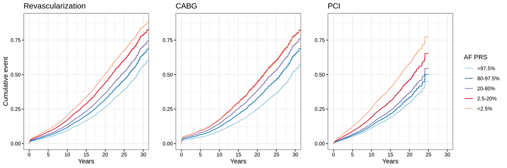

```r
oper="REVASC"
p1 <- my_ggcoxplot(fit.cxs2[[oper]], exp.cxs2[[oper]], "Revascularization", rev(my_labels), xlim=c(0,30), ylim=c(0,0.9), legend = "none")[["plot"]]

oper="CABG"
p2 <- my_ggcoxplot(fit.cxs2[[oper]], exp.cxs2[[oper]], str_glue("{oper}"), my_labels, xlim=c(0,30), ylim=c(0,0.9), legend="none", ylab="")[["plot"]]

oper="PCI"
p3 <- my_ggcoxplot(fit.cxs2[[oper]], exp.cxs2[[oper]], str_glue("{oper}"), my_labels, xlim=c(0,30), ylim=c(0,0.9), legend="none", ylab="")[["plot"]]

lgnd <- my_ggcoxplot(fit.cxs2[[oper]], exp.cxs2[[oper]], "Revascularization", rev(my_labels), legend="right", legend.title="AF PRS")[["plot"]] %>%
         get_legend()

plots2 <- grid.arrange(p1, p2, p3, lgnd, ncol = 4, widths = c(3,3,3,1))
```

```r
ggsave(file = str_glue("{fig_path}/cx.prs.af2.png"), plot = plots2, height = 3, width = 10, dpi = 300)
ggsave(file = str_glue("{fig_path}/cx.prs.af2.eps"), plot = plots2, device = cairo_ps, height = 3, width = 10, dpi = 300)
```

## 2.4 C-statistics for AF

**HR/1SD change:**

CA<sub>2</sub>HDS<sub>2</sub>-VASc only:

```r
my_cxlist_to_hrtable_selected(cxs.cs.cvsc, "Operation", select="_SCALED") %>%
  knitr::kable(digits=2) %>%
  kable_styling()
```

| Operation | Variable | HR (95% CI) | P-value |
| --- | --- | --- | --- |
| REVASC | CVSC_SCALED | 1.28 (1.23-1.34) | 3.8e-28 |
| CABG | CVSC_SCALED | 1.26 (1.19-1.34) | 2.3e-15 |
| PCI | CVSC_SCALED | 1.33 (1.25-1.41) | 5.6e-19 |

CA<sub>2</sub>HDS<sub>2</sub>-VASc+PRS:

```r
my_cxlist_to_hrtable_selected(cxs.cs.both, "Operation", select="_SCALED") %>%
  knitr::kable(digits=2) %>%
  kable_styling()
```

| Operation | Variable | HR (95% CI) | P-value |
| --- | --- | --- | --- |
| REVASC | AF_SCALED | 1.19 (1.15-1.23) | 6.8e-24 |
| REVASC | CVSC_SCALED | 1.29 (1.23-1.35) | 4.5e-29 |
| CABG | AF_SCALED | 1.16 (1.11-1.21) | 1.5e-11 |
| CABG | CVSC_SCALED | 1.27 (1.2-1.35) | 3.1e-16 |
| PCI | AF_SCALED | 1.22 (1.17-1.28) | 2.2e-17 |
| PCI | CVSC_SCALED | 1.33 (1.25-1.42) | 2.1e-19 |

**Cox plot: CA<sub>2</sub>HDS<sub>2</sub>-VASc + PRS**

Creating covariate combinations for the plot.

```r
exp.cs.cxs2 <-
  lapply(names_oper, function(oper){
       my_expand_cs_cvsc(cxs.both[[oper]],  "AF_SCALED", dfs.af[[oper]],
                  batch = "AxiomGT1_b44_V2.calls", agename=str_glue("{oper}_AGE"),
                  var_qs = quantile(dfs.af[[oper]][["AF_SCALED"]], c(0.9, 0.1)),
                  scr_qs = quantile(dfs.af[[oper]][["CVSC_SCALED"]], c(0.9, 0.1)))
  }) %>% setNames(names_oper)


fit.cs.cxs2 <-
  lapply(names_oper, function(oper){
        survfit(cxs.cs.both[[oper]], newdata = exp.cs.cxs2[[oper]])
}) %>% setNames(names_oper)
```

And the plot:

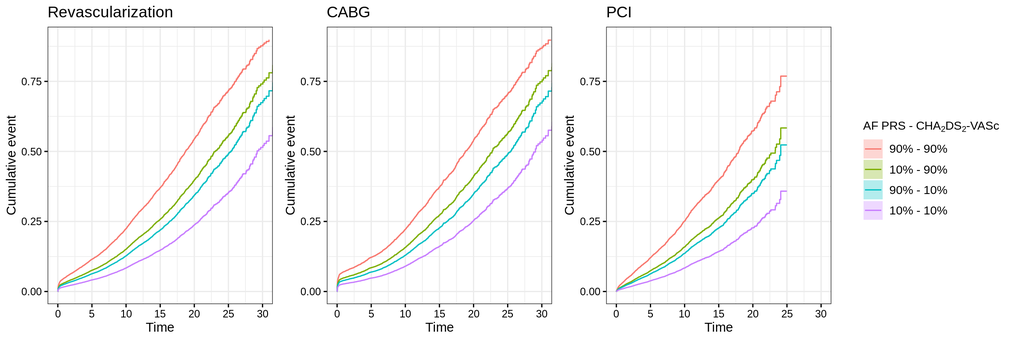

```r
label_name = expression('AF PRS - CHA'[2]*'DS'[2]*'-VASc')
lab_tmp = c("90% - 90%", "10% - 90%", "90% - 10%", "10% - 10%")
#palette=c("#C77CFF",  "#00BFC4",  "#7CAE00", "#F8766D") #ggplot default reversed

oper="REVASC"
p1 <- ggsurvplot(fit.cs.cxs2[[oper]], data =  exp.cs.cxs2[[oper]],
               fun = "event", censor = F, conf.int=F, ggtheme = theme_bw(),
               xlim=c(0,30), ylim=c(0,0.9), break.time.by=5, legend="none",
               size=0.5, font.tickslab=9.5, font.legend=9.5, title="Revascularization")[["plot"]]

oper="CABG"
p2 <- ggsurvplot(fit.cs.cxs2[[oper]], data =  exp.cs.cxs2[[oper]],
               fun = "event", censor = F, conf.int=F, ggtheme = theme_bw(),
               xlim=c(0,30), ylim=c(0,0.9), break.time.by=5, legend="none",
               size=0.5, font.tickslab=9.5, font.legend=9.5, title=oper)[["plot"]]

oper="PCI"
p3 <- ggsurvplot(fit.cs.cxs2[[oper]], data =  exp.cs.cxs2[[oper]],
               fun = "event", censor = F, conf.int=F, ggtheme = theme_bw(),
               xlim=c(0,30), ylim=c(0,0.9), break.time.by=5, legend="none",
               size=0.5, font.tickslab=9.5, font.legend=9.5, title=oper)[["plot"]]

lgnd <- ggsurvplot(fit.cs.cxs2[[oper]], data =  exp.cs.cxs2[[oper]], censor = F,
                   legend.title=label_name, legend.labs=lab_tmp, legend="right",
                   size=0.5, font.tickslab=9.5, font.legend=9.5)[["plot"]] %>%
        get_legend()

plots2 <- grid.arrange(p1,p2, p3, lgnd, ncol = 4, widths = c(3,3,3,2))
```

```r
ggsave(file = str_glue("{fig_path}/cx.prs.af.both.png"), plot = plots2, height = 3, width = 11, dpi = 300)
ggsave(file = str_glue("{fig_path}/cx.prs.af.both.eps"), plot = plots2, device = cairo_ps, height = 3, width = 10.6, dpi = 300)
```

**C-index**

```r
cindex_table <-
  lapply(names_oper, function(oper){
  compc<- compareC(timeX = dfs.af[[oper]][["AGE_DIFF"]],
                   statusX = dfs.af[[oper]][["AF"]],
                   scoreY= 1 - cxs.cs.both[[oper]][["linear.predictors"]], # '-' kääntää järjestyksen
                   scoreZ= 1 - cxs.cs.cvsc[[oper]][["linear.predictors"]])
  est <- prettify_estimate(estimate=compc$est.diff, stderr=sqrt(compc$est.vardiff_c), r=2)
  tibble(Name=oper, Cxy=round(compc$est.c[1],3), Cxz=round(compc$est.c[2],3),
         diff_est=est, diff_pval=signif(compc$pval,1))
}) %>%
do.call(rbind, .) %>%
select(Name, Cxz, Cxy, diff_est, diff_pval) %>%
rename(Procedure=Name, `CHA2DS2-VASc+PRS`=Cxy, `CHA2DS2-VASc`=Cxz, `Difference (95% CI)`=diff_est, `P-value`=diff_pval)

cindex_table %>%
knitr::kable() %>%
  kable_styling()
```

| Procedure | CHA2DS2-VASc | CHA2DS2-VASc+PRS | Difference (95% CI) | P-value |
| --- | --- | --- | --- | --- |
| REVASC | 0.668 | 0.676 | 0.0077 (0.0049-0.011) | 1e-07 |
| CABG | 0.668 | 0.673 | 0.0059 (0.0028-0.0089) | 2e-04 |
| PCI | 0.677 | 0.687 | 0.0098 (0.0056-0.014) | 6e-06 |

```r
#Felix: En nyt ole varma miksi tuo standard error lasketaan ottamalla varianssista neliöjuuri, eikä myös jakamalla samplen koon neliöjuurella. 'Normaalistihan' tuossa kaavassa pitäisi olla jakajana sqrt(var)/sqrt(n) eikä pelkkä sqrt(var). Koska CI myötäilee P-arvoa tapauksessa P=0.05, niin olen aika varma.
```

.